# BERD tutorial analysis - WGCNA

  # # Code chunk 9 #

```r
# Call an automatic merging function
merge = mergeCloseModules(datExpr, dynamicColors, cutHeight = MEDissThres, verbose = 3)
```

```
##  mergeCloseModules: Merging modules whose distance is less than 0.4
##    multiSetMEs: Calculating module MEs.
##      Working on set 1 ...
##      moduleEigengenes: Calculating 13 module eigengenes in given set.
##    multiSetMEs: Calculating module MEs.
##      Working on set 1 ...
##      moduleEigengenes: Calculating 9 module eigengenes in given set.
##    Calculating new MEs...
##    multiSetMEs: Calculating module MEs.
##      Working on set 1 ...
##      moduleEigengenes: Calculating 9 module eigengenes in given set.
```

```r
# The merged module colors
mergedColors = merge$colors;
# Eigengenes of the new merged modules:
mergedMEs = merge$newMEs;
```

# # Code chunk 10 #

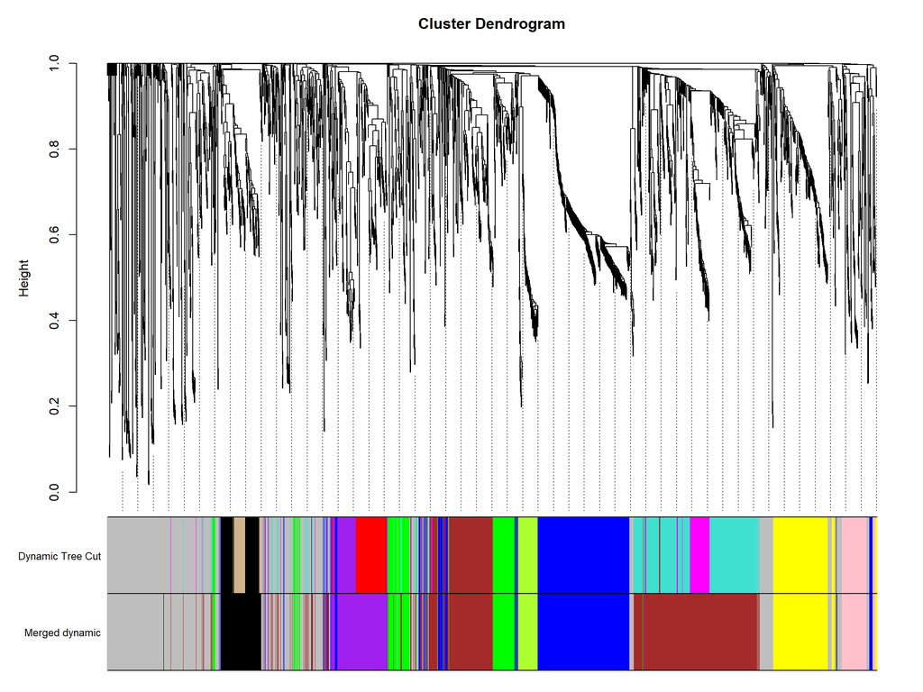

```r
#pdf(file = "Plots/geneDendro-3.pdf", wi = 9, he = 6)
plotDendroAndColors(geneTree, cbind(dynamicColors, mergedColors),
                    c("Dynamic Tree Cut", "Merged dynamic"),
                    dendroLabels = FALSE, hang = 0.03,
                    addGuide = TRUE, guideHang = 0.05)
```

```r
table(mergedColors)
```

```
## mergedColors
##       black        blue       brown       green greenyellow        grey
##         126         348         614         159          60         586
##        pink      purple      yellow
##          82         166         175
```

```r
table(dynamicColors)
```

```
## dynamicColors
##       black        blue       brown       green greenyellow        grey
##          83         348         178         159          60         586
##     magenta        pink      purple         red         tan   turquoise
##          82          82          68          98          43         354
##      yellow
##         175
```

```r
#dev.off()
```

# # Code chunk 11 #

```r
# Rename to moduleColors
moduleColors = mergedColors
# Construct numerical labels corresponding to the colors
colorOrder = c("grey", standardColors(50));
moduleLabels = match(moduleColors, colorOrder)-1;
MEs = mergedMEs;
# Save module colors and labels for use in subsequent parts
save(MEs, moduleLabels, moduleColors, geneTree, file = "Tutorial_Network.RData")

glimpse(MEs)
```

```
## Rows: 1,065
## Columns: 9
## $ MEgreen       <dbl> -0.026333683, 0.020044440, 0.014485888, 0.017023297, 0.0…
## $ MEblack       <dbl> 3.501647e-02, 1.890307e-02, -4.555147e-03, -3.840620e-02…
## $ MEpink        <dbl> 0.0130257102, -0.0252225636, -0.0357925149, -0.044253926…
## $ MEyellow      <dbl> 0.009851693, -0.020592669, -0.021381216, -0.029372961, -…
## $ MEpurple      <dbl> 0.0498141682, 0.0052709118, 0.0086866465, -0.0251802000,…
## $ MEgreenyellow <dbl> -0.0131012611, 0.0214110166, -0.0110909717, -0.019586948…
## $ MEblue        <dbl> 0.0398414287, -0.0049168145, -0.0169861495, -0.001507266…
## $ MEbrown       <dbl> 0.001610913, -0.024479322, -0.022386062, -0.004666227, -…
## $ MEgrey        <dbl> 0.0211657441, -0.0023759621, 0.0316704894, 0.0348926027,…
```

Determine which metabolites are hubs by determine which metabolites have extremely high kME values. *HUB METABOLIES*

# # Code chunk 12 #

```r
dim(datExpr)  # Should be (samples x metabolites)
```

```
## [1] 1065 2316
```

```r
dim(MEs)      # Should be (samples x modules)
```

```
## [1] 1065    9
```

```r
glimpse(rownames(datExpr))
```

```
##  chr [1:1065] "PZDa_S_85" "PZDa_S_88" "PZDa_S_91" "PZDa_S_93" "PZDa_S_94" ...
```

```r
glimpse(rownames(MEs))
```

```
##  chr [1:1065] "PZDa_S_85" "PZDa_S_88" "PZDa_S_91" "PZDa_S_93" "PZDa_S_94" ...
```

```r
# Check if the rownames match
all(rownames(MEs) == rownames(datExpr))
```

```
## [1] TRUE
```

```r
# Calculate module membership (kME) for each metabolite
geneModuleMembership = signedKME(datExpr, MEs)

# Use the module names from MEs for consistent labeling
colnames(geneModuleMembership) = paste0("k_", names(MEs))

# Calculate p-values for each kME
MMPvalue = corPvalueStudent(as.matrix(geneModuleMembership), nrow(datExpr))
colnames(MMPvalue) = paste0("pval_", names(MEs))

# Extract gene (metabolite) names (use column names of datExpr)
Gene = colnames(datExpr)

# Create the full kME table
kMEtable = data.frame(Metabolite = Gene,
                      Module = moduleColors,  # Correct module assignments
                      geneModuleMembership,
                      MMPvalue)

# Save the full kME and p-value table to CSV
write.csv(kMEtable, "kMEtable.csv", row.names = FALSE)

# Preview the first few rows to confirm - this is a matrux of metabolites and their modules
glimpse(kMEtable)
```

```
## Rows: 2,316
## Columns: 20
## $ Metabolite         <chr> "0.98_246.0843n", "0.58_419.8265n", "13.88_496.3606…
## $ Module             <chr> "brown", "brown", "blue", "blue", "brown", "brown",…
## $ k_MEgreen          <dbl> -0.36027094, -0.35475244, -0.53098989, -0.45574174,…
## $ k_MEblack          <dbl> -0.0054554404, -0.0156588762, 0.0315977507, 0.03924…
## $ k_MEpink           <dbl> 0.109841394, 0.105430971, 0.285663094, 0.243848657,…
## $ k_MEyellow         <dbl> 0.0744414329, -0.0446333080, 0.1602089314, 0.157317…
## $ k_MEpurple         <dbl> 0.125054722, 0.304308621, 0.185941281, 0.126563064,…
## $ k_MEgreenyellow    <dbl> 0.21040724, 0.15666782, 0.60568544, 0.33329969, 0.3…
## $ k_MEblue           <dbl> 0.30782365, 0.18560002, 0.91304456, 0.93151847, 0.3…
## $ k_MEbrown          <dbl> 0.342951584, 0.657222365, 0.460965931, 0.324555506,…
## $ k_MEgrey           <dbl> 0.048021310, 0.062925453, 0.052707254, -0.002645727…
## $ pval_MEgreen       <dbl> 5.471116e-34, 6.151541e-33, 1.616533e-78, 9.727640e…
## $ pval_MEblack       <dbl> 8.588589e-01, 6.097375e-01, 3.029077e-01, 2.006275e…
## $ pval_MEpink        <dbl> 3.290792e-04, 5.684491e-04, 1.900330e-21, 6.993766e…
## $ pval_MEyellow      <dbl> 1.510441e-02, 1.455051e-01, 1.470955e-07, 2.468353e…
## $ pval_MEpurple      <dbl> 4.270049e-05, 2.954250e-24, 9.695657e-10, 3.441129e…
## $ pval_MEgreenyellow <dbl> 4.027083e-12, 2.769275e-07, 1.272384e-107, 4.795017…
## $ pval_MEblue        <dbl> 8.270971e-25, 1.041478e-09, 0.000000e+00, 0.000000e…
## $ pval_MEbrown       <dbl> 9.277134e-31, 1.072368e-132, 3.833801e-57, 1.517343…
## $ pval_MEgrey        <dbl> 1.173002e-01, 4.005766e-02, 8.557041e-02, 9.312754e…
```

# # Code chunk 13 #

```r
# Initialize list to store top hub genes per module
topGenesKME = list()

# Extract module names from the kME matrix
module_names = colnames(geneModuleMembership)

# Loop through each module to identify top hub genes
for (module in module_names) {

  # Rank genes within the module (higher kME is better for hubs)
  kMErank = rank(-geneModuleMembership[, module])

  # Extract the top 10 hub genes
  topGenes = Gene[kMErank <= 10]

  # Store in the list
  module_name_cleaned = sub("kME_", "", module)
  topGenesKME[[module_name_cleaned]] = topGenes
}

# Convert the list to a data frame for easier viewing
topGenesKME_df = as.data.frame(topGenesKME)

# Save the top hub genes to a CSV file
write.csv(topGenesKME_df, "TopGenesKME.csv", row.names = FALSE)

# Preview the top hub genes
print(topGenesKME_df)
```

```
##            k_MEgreen         k_MEblack         k_MEpink       k_MEyellow
## 1   15.73_1076.6325n   16.46_518.3959n   7.47_804.2939n  9.02_2701.4045n
## 2   15.73_1074.6313n   16.63_492.3793n   7.47_802.3351n  9.07_1614.3386n
## 3  15.73_541.3281m/z   16.36_422.3383n   7.47_786.3214n 9.02_681.8531m/z
## 4  15.56_496.1383m/z   16.66_517.3851n   7.47_770.3546n 9.02_682.1037m/z
## 5  15.73_289.6587m/z   16.74_426.3696n 7.47_386.1796m/z 9.02_691.5906m/z
## 6  15.56_498.3446m/z   16.44_482.3589n 7.47_406.1579m/z 9.02_687.5989m/z
## 7  15.58_787.9867m/z 16.39_493.3876m/z 3.45_489.2302m/z 9.02_691.3398m/z
## 8  15.73_545.3400m/z 16.76_543.4013m/z 7.47_387.1731m/z 9.02_687.3484m/z
## 9  15.32_522.3449m/z 16.44_489.3542m/z 7.47_401.6500m/z 9.02_695.3318m/z
## 10 15.73_524.3607m/z 16.31_487.3386m/z 7.47_749.3829m/z 9.07_819.4181m/z
##           k_MEpurple   k_MEgreenyellow         k_MEblue         k_MEbrown
## 1    16.24_388.2080n   11.19_528.3508n  14.90_978.6689n   13.12_330.2397n
## 2    16.24_300.1973n   10.53_514.3349n  15.22_948.6584n    0.55_203.9617n
## 3    16.21_337.1660n   10.28_470.3089n  15.03_758.5372n    0.55_271.9489n
```

[output cut: 18 more lines]

# # Code chunk 14 #

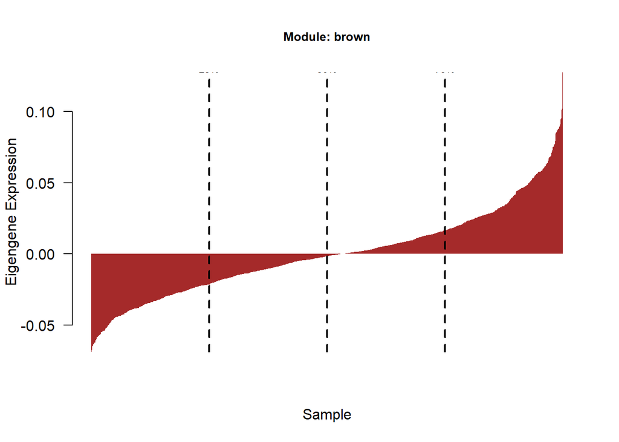

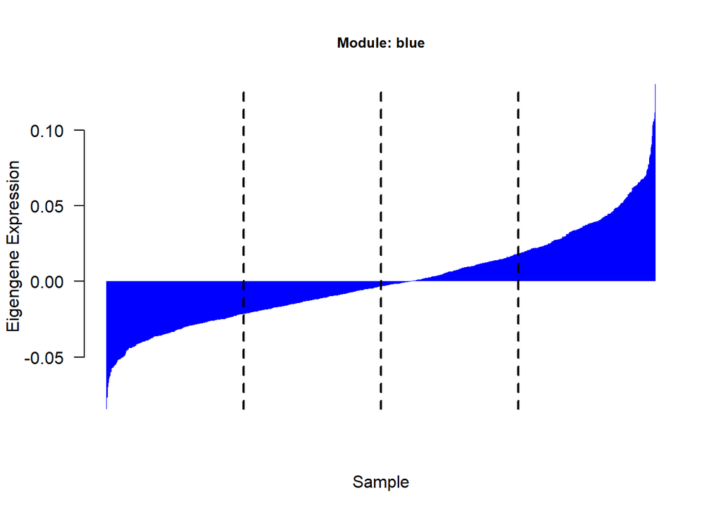

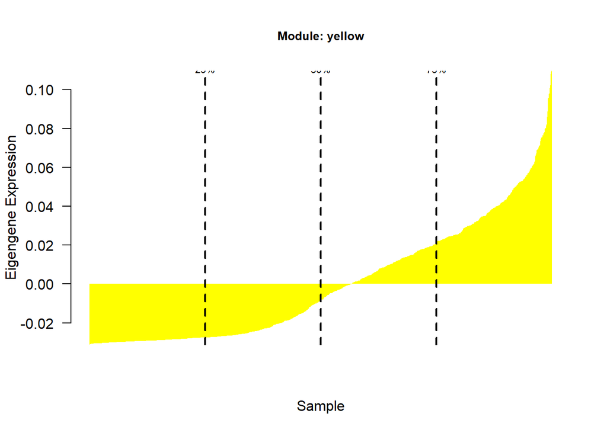

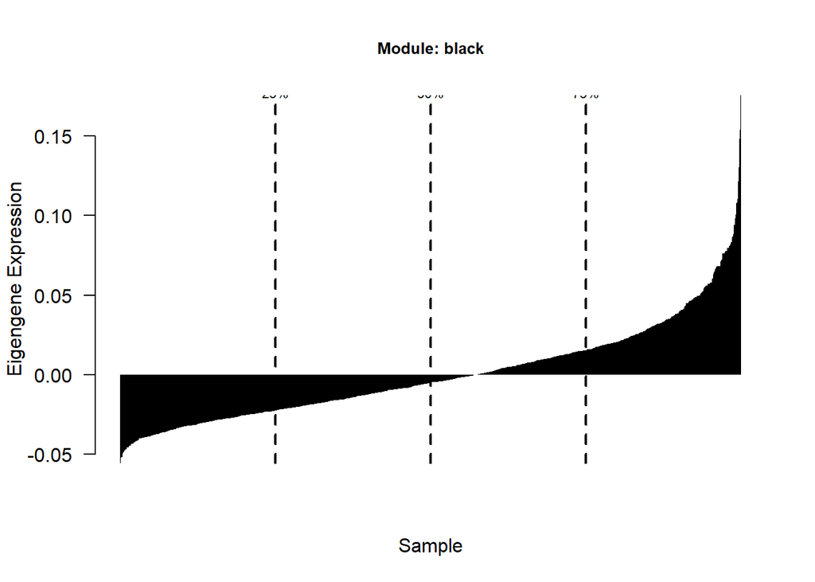

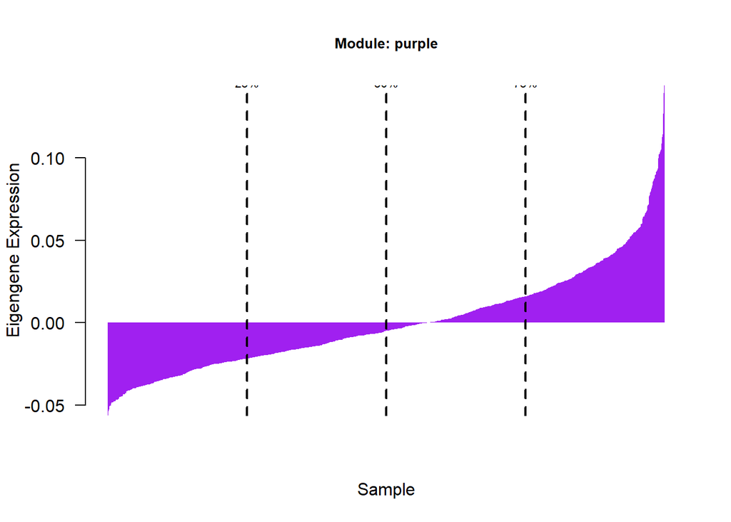

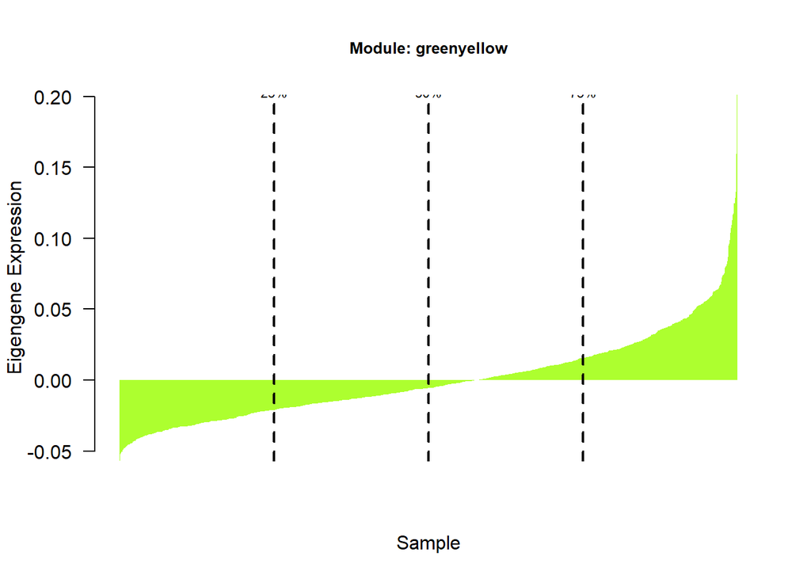

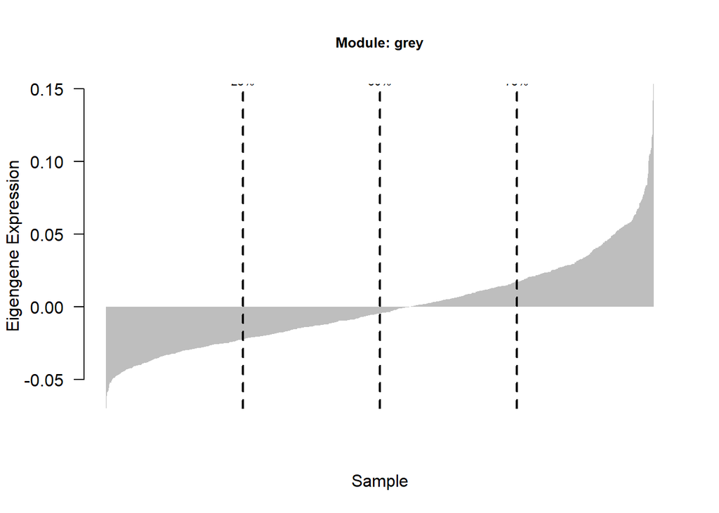

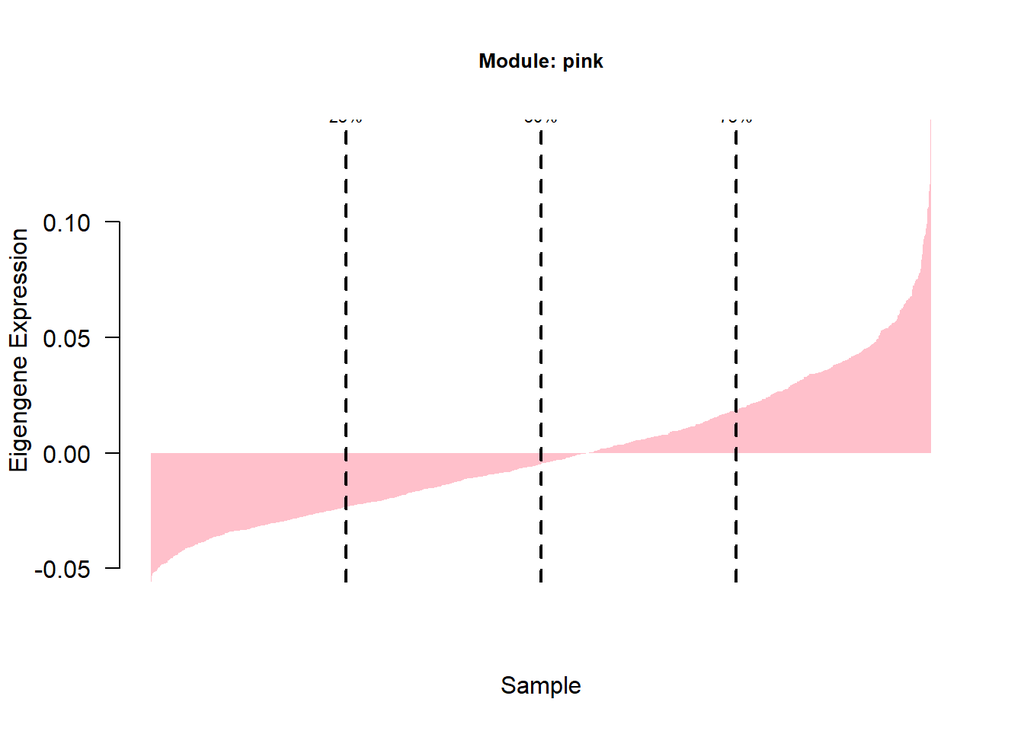

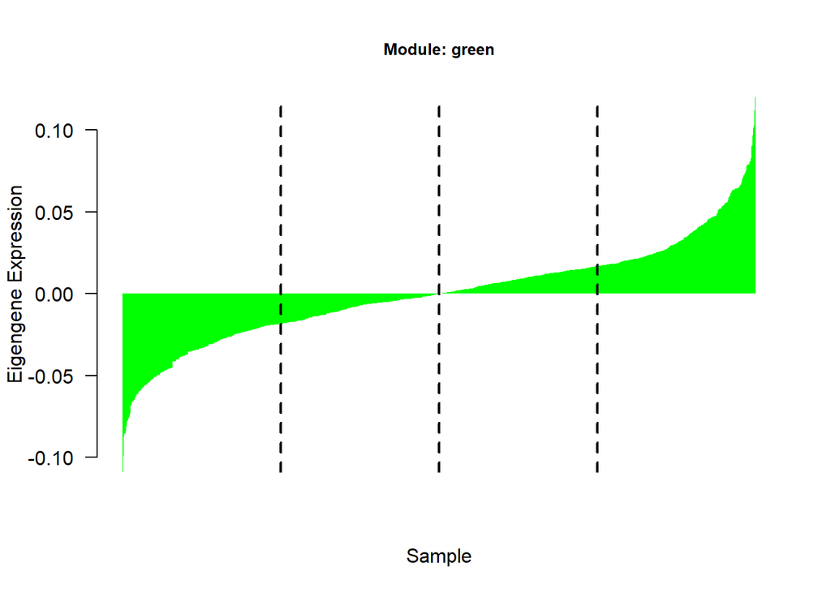

```r
# Loop through each module
for (module in unique(mergedColors)) {

  # Extract the ME for the current module
  ME_values = MEs[, paste0("ME", module)]

  # Order the samples by ME values
  ordered_indices = order(ME_values)
  ordered_ME_values = ME_values[ordered_indices]

  # Create the bar plot
  bp = barplot(ordered_ME_values,
               col = module,
               main = paste("Module:", module),
               cex.main = 0.8,
               ylab = "Eigengene Expression",
               xlab = "Sample",
               border = NA,
               las = 2)

  # Calculate the 25th, 50th, and 75th percentiles
  n_samples = length(ordered_ME_values)
  quantiles = quantile(1:n_samples, probs = c(0.25, 0.5, 0.75))

  # Add vertical lines at the quantiles
  abline(v = bp[quantiles], col = "black", lty = 2, lwd = 2)

  # Add percentile labels
  text(x = bp[quantiles], y = max(ordered_ME_values) * 0.95,
       labels = c("25%", "50%", "75%"),
       pos = 3, cex = 0.7, col = "black")
}
```

- Code chunk 15
- correlations with clinical data. This will not work because of data access issues

*sample of the clinical characteristics available.

**Heat map of the correlation between metabolites and covariates**

We check these associations to assess whether we should be dropping any modules or focusing in on certain modules.

```r
#check if row names and IDs are the same
identical(rownames(MEs), trts.outcms.impscl.1$sample_name)
```

```
## [1] TRUE
```

```r
#more data chekcs
nSamples <- nrow(datExpr)
nMets <- ncol(datExpr)

#move sample names to row names and drop
trts.outcms.impscl.1 <- column_to_rownames(trts.outcms.impscl.1, var="sample_name")

#pearson correlation
module.covars.corr <- cor(MEs, trts.outcms.impscl.1, use = "p")
module.covars.corr.pvals <- corPvalueStudent(module.covars.corr, nSamples)
glimpse(module.covars.corr.pvals)
```

```
##  num [1:9, 1:15] 0.00995 0.928065 0.153637 0.012022 0.000927 ...
##  - attr(*, "dimnames")=List of 2
##   ..$ : chr [1:9] "MEgreen" "MEblack" "MEpink" "MEyellow" ...
##   ..$ : chr [1:15] "gdm" "iom_cat" "lga" "rcluster_5" ...
```

```r
library(CorLevelPlot)
covars.heatmap.data <- merge(MEs, trts.outcms.impscl.1, by = "row.names")
glimpse(covars.heatmap.data) # i use this to see what I want on the X axis and Y axis. We have 9 MEs so i'll but them on X
```

```
## Rows: 1,065
## Columns: 25
## $ Row.names                  <I<chr>> PZDa_S_1001, PZDa_S_1003, PZDa_S_1005, P…
## $ MEgreen                    <dbl> -0.021618942, 0.018405146, -0.018922676, 0.…
## $ MEblack                    <dbl> -0.007876516, -0.047442911, -0.028816217, -…
## $ MEpink                     <dbl> 0.0538291011, 0.0358926427, 0.0364738487, -…
## $ MEyellow                   <dbl> -0.026454768, 0.031920710, 0.026060546, -0.…
## $ MEpurple                   <dbl> 0.0457485916, -0.0283178285, -0.0217916585,…
## $ MEgreenyellow              <dbl> 0.016721899, 0.004534125, -0.008940749, -0.…
## $ MEblue                     <dbl> -0.032480849, -0.024252959, 0.001972847, -0…
## $ MEbrown                    <dbl> 0.0238913799, -0.0097451358, -0.0097426841,…
## $ MEgrey                     <dbl> 0.008624931, -0.020392738, 0.040357893, -0.…
## $ gdm                        <int> 0, 0, 0, 0, 0, 0, 0, 0, 0, 0, 0, 0, 0, 0, 0…
## $ iom_cat                    <int> 2, 3, 3, 2, 1, 2, 3, 1, 1, 3, 3, 3, 1, 2, 1…
## $ lga                        <int> 0, 0, 0, 0, 0, 0, 0, 0, 0, 0, 0, 0, 0, 0, 0…
## $ rcluster_5                 <int> 3, 2, 2, 1, 4, 2, 3, 5, 1, 4, 2, 4, 3, 1, 1…
## $ iom_bin                    <int> 0, 1, 1, 0, 0, 0, 1, 0, 0, 1, 1, 1, 0, 0, 0…
## $ pbmi                       <dbl> 2.0030294, 0.3376484, -0.8035221, -0.787710…
## $ chol_ipv1                  <dbl> 1.60989303, 4.32357042, 2.00155781, -1.2436…
## $ ffa_ipv1                   <dbl> 1.24357392, -0.67034861, -0.15758432, -1.35…
## $ hdl_ipv1                   <dbl> 0.21668170, 1.14957087, 1.22731164, -0.3275…
## $ ldl_ipv1                   <dbl> 1.574549996, 4.713340706, 1.337396920, -1.1…
## $ trig_ipv1                  <dbl> 1.1461310, 0.6587834, 1.9063933, -0.6668022…
## $ ipv1_averaged_tnfa__pg_ml_ <dbl> 0.1327643, -0.3741861, 0.7611188, -0.243572…
## $ homa_ir_ipv1               <dbl> 0.30868351, -0.12923210, -0.93207738, -0.97…
## $ insu_ipv1                  <dbl> 0.58526399, -0.13999357, -0.98612738, -0.98…
## $ gluc_ipv1                  <dbl> -1.11340679, 0.19013894, -0.24437630, -1.11…
```

```r
dim(covars.heatmap.data)
```

```
## [1] 1065   25
```

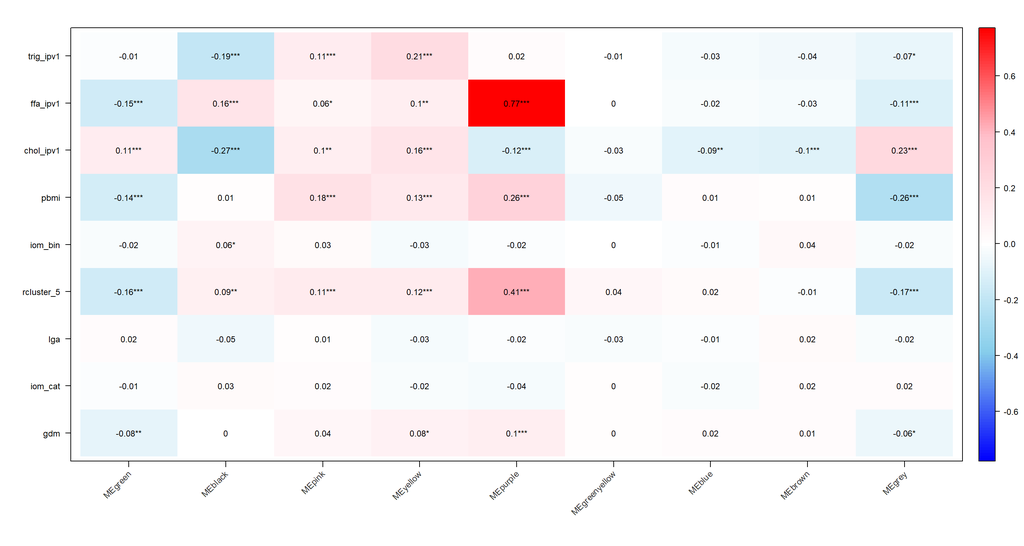

```r
#move ids back to row name
covars.heatmap.data <-covars.heatmap.data %>%
  column_to_rownames(var = "Row.names")

CorLevelPlot(covars.heatmap.data,
             x =names(covars.heatmap.data)[1:9],
             y= names(covars.heatmap.data)[c(10:17,20)], #if you just want to select certain variables
             col = c("blue1", "skyblue", "white", "pink", "Red"),
            cexLabX = .75,
            rotLabX = 45,
            colLabX = "grey20",
            fontLabX = 1,
            cexLabY = .75,
            fontLabY = 1,
        cexCorval = .75,
        fontCorval = .5,
        cexLabColKey = .75)
```

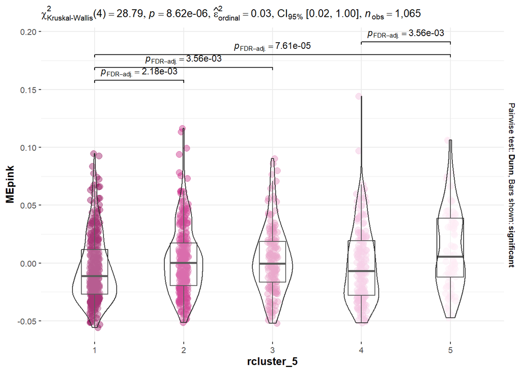

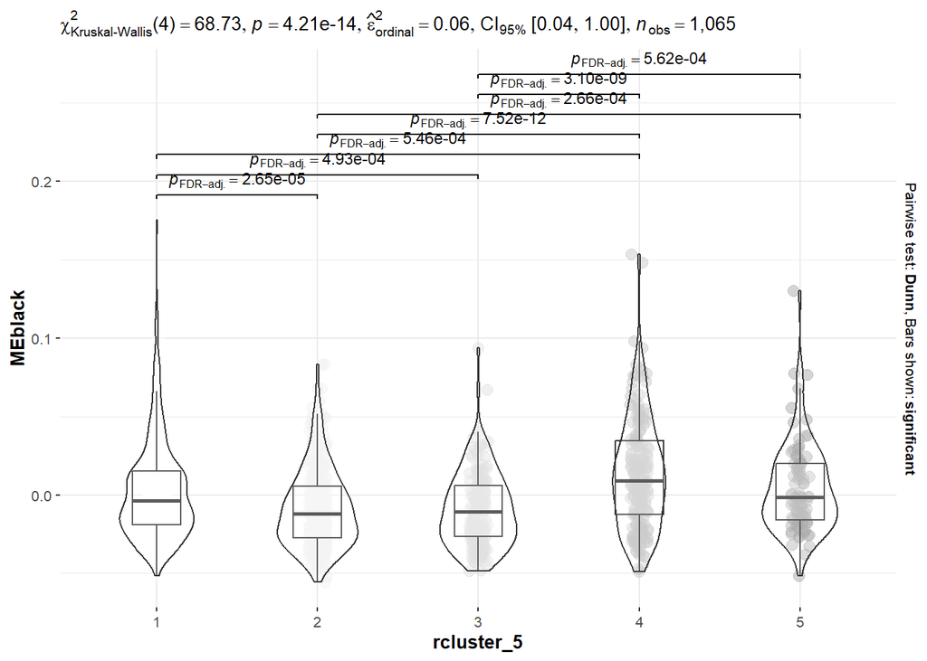

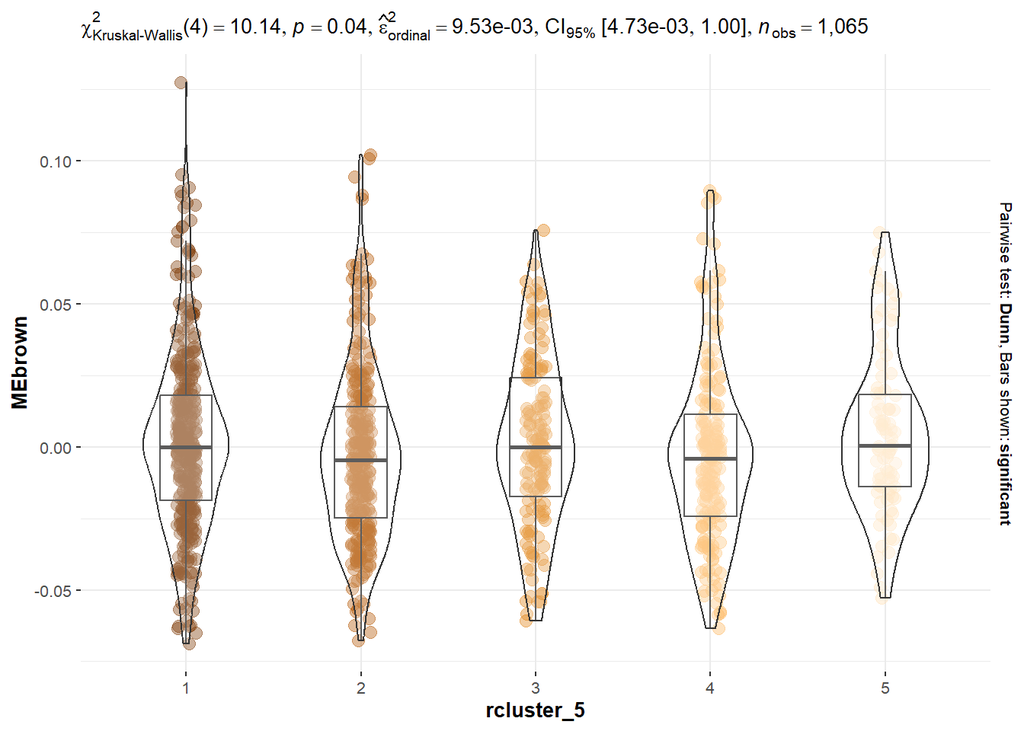

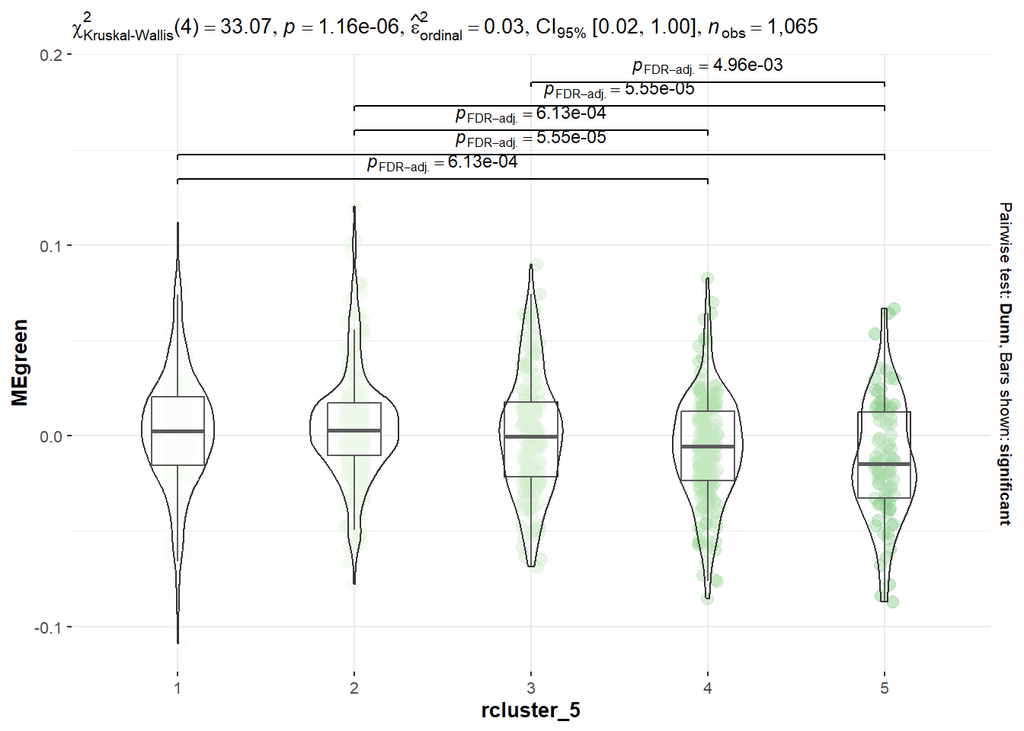

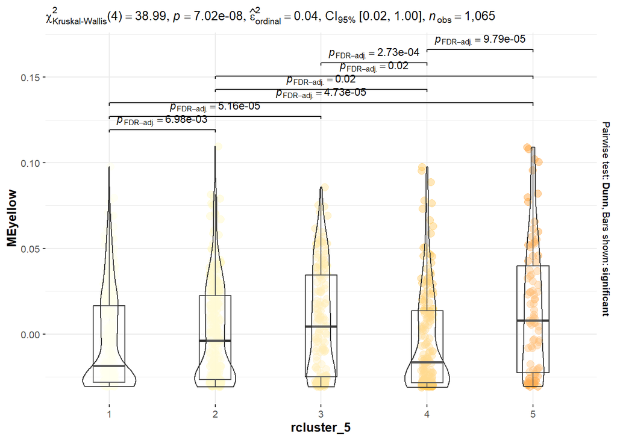

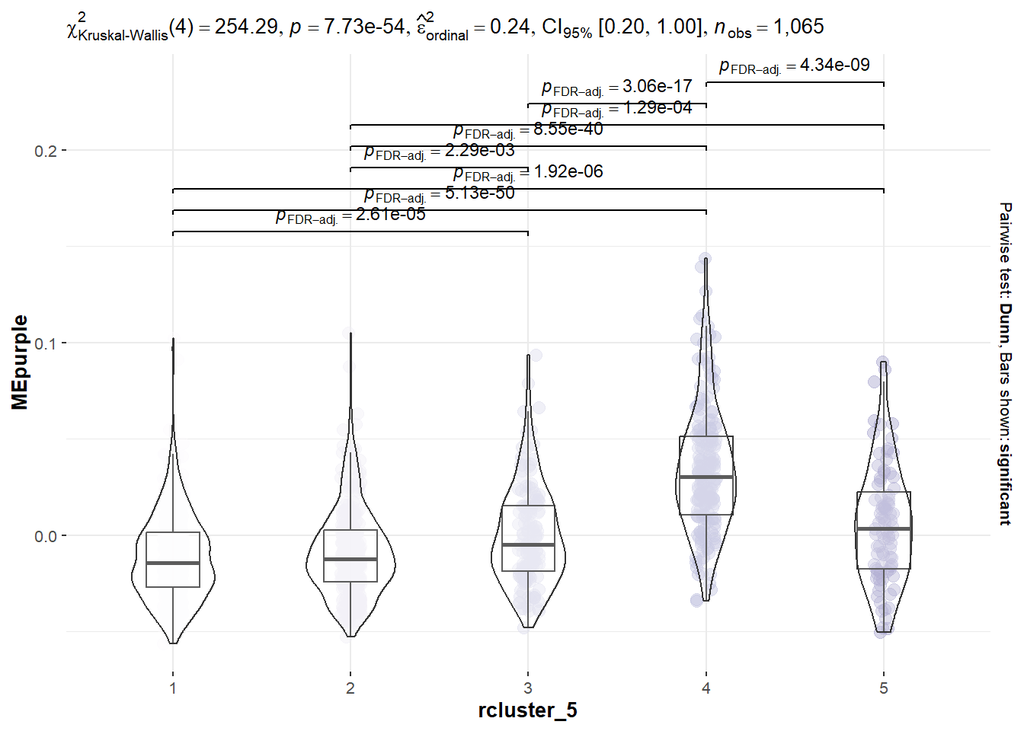

```r
# Extract only the relevant ME columns and the grouping variable
ME_colors <- c("MEpink", "MEblack", "MEbrown", "MEgreen", "MEyellow", "MEpurple")
ME.exprs <- select(covars.heatmap.data, all_of(ME_colors), rcluster_5)

# Define color palettes for each module
color_palettes <- c(
  "MEpink" = "PiYG",
  "MEblack" = "Greys",
  "MEred" = "RdGy",
  "MEgreen" = "Greens",
  "MEyellow" = "YlOrBr",
  "MEbrown" = "PuOr",
  "MEblue" = "Blues",
  "MEturquoise" = "YlGnBu",
  "MEpurple" = "Purples"
)

# Generate plots using a loop
plot_list <- list()

for (ME in ME_colors) {

  plt <- ggbetweenstats(
    data = ME.exprs,
    x = rcluster_5,
    y = !!sym(ME),
    type = "nonparametric",
    plot.type = "box",
    pairwise.comparisons = TRUE,
    pairwise.display = "s",
    p.adjust.method = "fdr",
    var.equal = FALSE,
    centrality.plotting = FALSE,
    bf.message = FALSE,
    package = "RColorBrewer",
    palette = color_palettes[ME]
  )

  # Store the plot in the list
  plot_list[[ME]] <- plt

  # Print each plot (optional)
  print(plt)
}
```

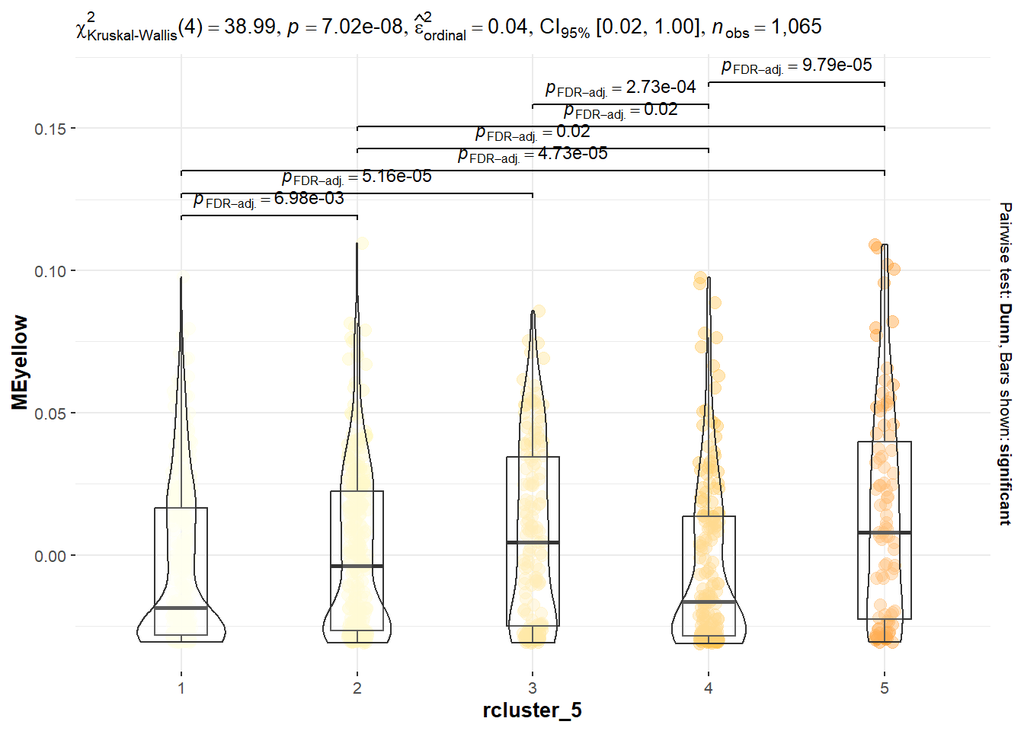

```r
# Access individual plots if needed
plot_list$MEyellow
```